# Chpater 5 Exercises

Iris

2020/4/26

## Question 3

In this question we simulate the rolling of a die.  
To do this we use the function runif(1), which returns a ‘random’ number in the range (0,1).  
To get a random integer in the range {1, 2, 3, 4, 5, 6}, we use ceiling(6*runif(1)), or if you prefer, sample(1:6,size=1) will do the same job.

(a).  
Suppose that you are playing the gambling game of the Chevalier de M´er´e.  
That is, you are betting that you get at least one six in 4 throws of a die.  
Write a program that simulates one round of this game and prints out whether you win or lose.  
Check that your program can produce a different result each time you run it.

```r
#a
x <- seq(1:4)  #將x隨意放入數字,此為{1,2,3,4}
flag <- 0  #歸零,以下將用來表示成功與否
for(i in seq(1:4))  #擲骰子4次
  x[i] <- sample(1:6,size=1)  #將每次的值,按照順序存入x中
print(x)  #將骰子結果輸出
```

```
## [1] 4 5 2 2
```

```r
for(i in range(1:4))  #從第一個骰子的值開始,一一確認是否=6
  if(x[i]==6)  #若為6
    flag <- flag + 1  #則將紀錄成功次數+1
if(flag>=1)  #表示有成功
  {print("win")}  #顯示win
if(flag == 0)  #成功次數=0,表示失敗
  {print("lose")} #顯示lose
```

```
## [1] "lose"
```

(b).  
Turn the program that you wrote in part (a) into a function sixes,  
which returns TRUE if you obtain at least one six in n rolls of a fair die,and returns FALSE otherwise.  
That is, the argument is the number of rolls n,  
and the value returned is TRUE if you get at least one six and FALSE otherwise. How would you give n the default value of 4?

```r
#b
x <- seq(1:4)
flag <- 0
sixes <- function(n) {
  for(i in seq(1:n))
  {
    x[i] <- sample(1:6,size=1)
    if(x[i]==6)
      flag <- flag + 1
  }
  print(x)
  if(flag >= 1)
    {return(TRUE)}  #成功回傳TRUE
  else
    {return(FALSE)}  #失敗回傳FALSE
}
print(sixes(4))  #輸出擲骰子4次的結果
```

```
## [1] 4 1 6 1
## [1] TRUE
```

(c).  
Now write a program that uses your function sixes from part (b),  
to simulate N plays of the game (each time you bet that you get at least 1 six in n rolls of a fair die).  
Your program should then determine the proportion of times you win the bet.  
This proportion is an estimate of the probability of getting at least one 6 in n rolls of a fair die.  
Run the program for n = 4 and N = 100, 1000, and 10000, conducting several runs for each N value.  
How does the variability of your results depend on N?  
The probability of getting no 6’s in n rolls of a fair die is (5/6)n,  
so the probability of getting at least one is 1 − (5/6)n.  
Modify your program so that it calculates the theoretical probability as well as the simulation estimate and prints the different.

```r
#begin with (b)
x <- seq(1:4)
flag <- 0
sixes <- function(n) {
  for(i in seq(1:n))
  {
    x[i] <- sample(1:6,size=1)
    if(x[i]==6)
      flag <- flag + 1
  }
  if(flag >= 1)
    {return(TRUE)}
  else
    {return(FALSE)}
}#end with (b)

t <- 0  #歸零,紀錄成功次數
N <- 100 #or 1000 or 10000
for(j in seq(1:N))  #計算1-N局,每局擲骰子4次
{
  if(sixes(4)==TRUE)  #若有1局成功
    {t <- t + 1}  #紀錄成功次數+1
}
p <- t/N  #總成功數/總局數計算=成功機率
print(p) #輸出成功機率
```

```
## [1] 0.53
```

```r
th <- 1-(5/6)^4  #理論值
print(abs(p-th))  #實驗-理論相差多少
```

```
## [1] 0.01225309
```

(d).  
Write a program to write the result of all N runs to a textfile ‘sixes_sim.txt’, with the result of each run on a separate line.  
Now write another program to read the textfile sixes_sim.txt and again determine the proportion of bets won.

```r
#begin with (b)
x <- seq(1:4)
flag <- 0
sixes <- function(n) {
  for(i in seq(1:n))
  {
    x[i] <- sample(1:6,size=1)
    if(x[i]==6)
      flag <- flag + 1
  }
  print(x)
  if(flag >= 1)
    {return(TRUE)}
  else
    {return(FALSE)}
}#end with (b)

N <- 100 #or 1000 or 10000(局)遊戲
r <- logical(N) #將布林值處存至r
for(j in seq(1:N))  #將N局,每局投擲4次骰子結果紀錄
  r[j] <- sixes(4)
```

```
## [1] 2 2 1 3
## [1] 5 1 6 1
## [1] 4 4 1 3
## [1] 6 4 6 3
## [1] 5 2 1 3
## [1] 5 4 5 2
## [1] 5 4 4 4
## [1] 5 2 5 6
## [1] 5 1 2 6
## [1] 6 1 1 4
## [1] 3 6 4 4
## [1] 5 2 1 2
## [1] 1 4 6 3
## [1] 2 5 1 1
## [1] 2 5 3 1
```

[output cut: 85 more lines]

```r
write(r, file="sixes_sim.txt",sep="\n") #紀錄實驗結果
result <- read.table("sixes_sim.txt") #讀取實驗結果

t <- 0 #歸零,用來紀錄贏的次數
for(j in seq(1:N))  #計算贏的比例
  if(result[j, 1]==TRUE)
    {t <- t + 1}
print(t/N) #輸出贏的比例
```

```
## [1] 0.5
```

## Question 5

For r ∈ [0, 4], the logistic map of [0, 1] into [0, 1] is defined as f(x) = rx(1 − x).  
Given a point $x_{1}$ ∈ [0, 1] the sequence given by $x_{n+1}$ = f($x_{n}$) is called the discrete dynamical system defined by f.  
Write a function that takes as parameters $x_{n+1}$, r, and n, generates the first n terms of the discrete dynamical system above, and then plots them.  
The logistic map is a simple model for population growth subject to resource constraints:  
if $x_{n}$ is the population size at year n, then $x_{n+1}$ is the size at year n+1.  
Type up your code, then see how the system evolves for different starting values $x_{1}$ and different values of r.

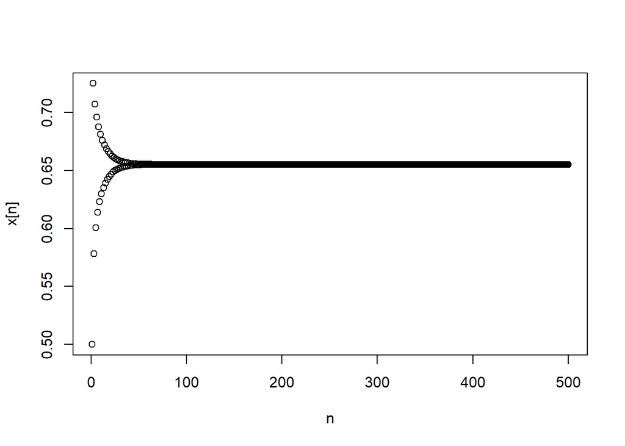

```r
logistic_map <- function(r, x, n){
  temp <- numeric(n) #將n個點存至temp
  temp[1] <- x #令temp第一個值,也就是起始值為1(題目所述)
  for(i in c(2:n)) #從temp中2至n的位置存入計算後的值
    temp[i] <- r*temp[i-1]*(1-temp[i-1])
  return(temp) #回傳所有存至temp中的值
}
value_r <- 2.9 #設1-4的數
value_x <- 0.5 #設0-1的數
value_n <- 500 #取500個點作圖
result <- logistic_map(value_r, value_x, value_n) #帶入上述logistic_map函數計算y點
plot(c(1:value_n), result, type="p", xlab="n", ylab="x[n]") #作圖
```

## Question 7

The number of ways you can choose r things from a set of n, ignoring the order in which they are chosen, is $\binom{n}{r}$ = n!/(r!(n − r)!).  
Let x be the first element of the set of n things.  
We can partition the collection of possible size r subsets into those that contain x and those that don’t:  
there must be $\binom{n-1}{r-1}$ subsets of the first type a $\binom{n-1}{r}$ subsets of the second type.  
Thus, $\binom{n}{r}$ = $\binom{n-1}{r-1}$ $\binom{n-1}{r}$.  
Using this and the fact $\binom{n}{n}$ = $\binom{n}{0}$ = 1, write a recursive function to calculate $\binom{n}{r}$.

```r
#recursive function:
nfact <- function(num) {  #做階乘運算
    if (num == 1) {return(1)}  #num=1時跳出,完成遞迴
    else {return(num*nfact(num-1))}  #回傳num*(num-1)!
 }
n <- 6 #代任意整數或換成輸入
r <- 4 #代任意整數或換成輸入
print(nfact(n)/nfact(r)/nfact(n-r)) #輸出C n取r結果
```

```
## [1] 15
```

End of chpater 5 exercises.